# VL02: Datentypen, Strukturen, Funktionen

IFM 3.3 Systemprogrammierung, W19

Carsten Gips, FH Bielefeld

# Wiederholung

## C-Basics

- Wie komme ich vom C-Quelltext zum ausführbaren Programm?
- Was macht die `#include`-Direktive?

# Motivation

## Warum ist das gefährlich?

```c
if (i=3)
    printf("Vorsicht");
else
    printf("Vorsicht (auch hier)");
```

## Sinn von Klassen?

**Kapselung von Daten und Operationen auf Daten**

```java
public class Studi {
    private String name;
    private int credits;

    public Studi(String name, int credits) { ... }
    public int getCredits() { ... }
    ...
}
```

**C kennt keine Klassen**: Wie Daten und Operationen kapseln??

- Benutzerdefinierte Datentypen (Strukturen)
- Funktionen

## Themen für heute

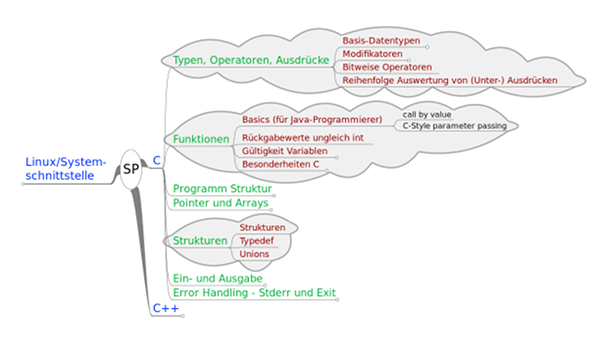

Am Ende der VL können/verstehen Sie:

- C-Basics, wichtigste Unterschiede zu Java
- Definition eigener Datenstrukturen in C
- Deklaration und Definition von Funktionen
- Unterschiede zw. lokalen und globalen Variablen, Lebensdauer und Initialisierung

# Datentypen, Kontrollfluss und Operatoren

## Variablen, Operatoren, Kontrollfluss

**Im Wesentlichen wie von Java gewohnt … :-)**

- Wichtig(st)e Abweichungen:
  1. ANSI-C: Deklaration **aller Variablen** am **Anfang** eines Blocks
  2. Im booleschen Kontext wird `int` als Wahrheitswert interpretiert: Alle Werte ungleich 0 entsprechen `true` (!)

=> Vorsicht mit

```c
int c;
if (c=4) { ... }
```

Beispiel für Schleifen und Kontrollstrukturen in C:

```c
int x=5, y=1;


if (x>5) {
    x++;
} else if(y<=1) {
    y = y-x;
} else {
    y = 2*x;
}


while (y>0) {
    y--;
}


for (x=0; x<10; x++) {
    y = y*y;
}
```

## Basisdatentypen

| `char` | Zeichen (ASCII, 8 Bit bzw. 1 Byte) |
| --- | --- |
| `int` | Ganze Zahl (16, 32 oder 64 Bit) |
| `float` | Gleitkommazahl (typ. 32 Bit) |
| `double` | Doppelt genaue Gleitkommazahl (typ. 64 Bit) |
| `void` | Ohne/kein Wert |

Außerdem Arrays und Pointer mit diesen Typen möglich.

Und was ist mit booleschen Werten?

- Es gibt kein `bool` (erst ab C99: als Makro)!

  => Nehmen Sie `int` …

  Alle Werte ungleich 0 werden im booleschen Kontext als `true` interpretiert.

  *Achtung*: Ein Rückgabewert von 0 wird in der Regel als *Erfolg* betrachtet!

Konsole: vl02/bool.c

## Typmodifikatoren ändern Bedeutung

Vorangestellte Modifikatoren ändern Bedeutung:

- Länge im Speicher

  | `short` | Speicher: halbe Wortlänge |
  | --- | --- |
  | `long` | Speicher: doppelte/dreifache Wortlänge |

- Vorzeichen

  | `signed` | mit Vorzeichen (Default bei Zahlen) |
  | --- | --- |
  | `unsigned` | ohne Vorzeichen |

Anwendung auf ganze Zahlen und Doubles:

- `short` und `long` sind Synonyme für `short int` und `long int`
- `long long` ist typischerweise eine ganze Zahl mit 8 Byte
- `unsigned char` sind Zahlen von 0, …, 255 (1 Byte)
- `long double` (nur diese Form)

## Größe eines Datentyps ist maschinenabhängig

**Der reservierte Speicherbereich und damit auch der Zahlenbereich für einen einfachen Typ in C ist maschinenabhängig!**

Konsole: vl02/limits.c

## Ausgabe mit printf()

- `printf(formatstring, ...)`
  1. Format-String: Text und Formatierung der restlichen Parameter
  2. Weitere auszugebende Parameter
- Format-String: `%[flags][width][.precision]conversion`
  - `flags`: hängt von der konkreten Ausgabe ab
  - `width`: Feldbreite
  - `precision`: Anzahl der Dezimalstellen
  - `conversion`: (Beispiele)

    | c | Zeichen (Char) |
    | --- | --- |
    | d | Integer (dezimal) |
    | f | Gleitkommazahl |

Konsole: vl02/printf.c

## Operatoren (bitweise)

| `a & b` | bitweise AND (Löschen von Bits, Maske: 0) |
| --- | --- |
| `a \| b` | bitweise OR (Setzen von Bits, Maske: 1) |
| `a ^ b` | bitweise Exklusiv-OR (Invertieren von Bits, Maske: 1) |
| `~a` | bitweise Negation (Invertieren aller Bits) |
| `a << n` | alle Bits $n$ Positionen nach links schieben, Auffüllen mit 0 |
| `a >> n` | alle Bits $n$ Positionen nach rechts schieben, Auffüllen maschinenabhängig |

Operatoren wirken bitweise auf `char`, `short`, `int`, `long`

**Beispiel:** Stellen Sie sich einen 8-Bit-Port vor, an dem 8 LED hängen:

- Wenn Sie gezielt eine LED ausschalten wollen, nutzen Sie ein bitweises AND und in der Maske eine 0 an der Position der LED.
- Umgedreht für das Einschalten: verODERn Sie den Port-Wert bitweise mit einer Maske, wo an der Position der LED eine 1 steht.

Tafel/Aufgabe: Port ansteuern; Konsole: vl02/bitop.c

## Typische Header

| `stdlib.h` | Allgemeine Hilfsmittel | `malloc()`, `free()`, `rand()` |
| --- | --- | --- |
| `stdio.h` | Ein- und Ausgabe | `printf()`, Dateimanipulation |
| `math.h` | Mathe-Standardfunktionen | `sin()` |
| `limits.h` | Größen der Typen | `INT_MAX` |
| `string.h` | Umgang mit Zeichenketten | `strlen()` |

*Hinweis*: `man <funktion>` zeigt u.a an, woher die Funktion stammt :-)

*Konvention*: `malloc(3)` meint Man-Page Seite 3, also `man 3 malloc`

## Alias-Namen für Typen mit typedef

- Syntax: `typedef existTyp neuerName;`

  ```c
  typedef unsigned long uint32;
  uint32 x, y, z;
  ```

# Datenstrukturen in C

## Benutzerdefinierte Datentypen in C

- Strukturen kapseln Daten: Schlüsselwort `struct`

  ```c
  struct point {
      int x;
      int y;
  } a;
  ```

  - Im Beispiel Definition der Struktur `point` sowie einer Variablen `a` vom Typ `struct point`.
  - Bei gleichzeitiger Definition einer Variablen kann auch der Name der Struktur weggelassen werden (“anonyme Struktur”).
  - Bestandteile (“Member”) einer Struktur werden **nacheinander** im Speicher angeordnet. Unter Umständen gibt es dabei ein “Alignment” (Ausrichtung) der Komponenten an bestimmten Speichergrößen/-blöcken (=> siehe spätere Vorlesung)
- Variablendefinition

  ```c
  struct point b;
  ```

- Zugriff auf Daten

  ```c
  a.x = 10; a.y = 10;
  b.x = 42; b.y = 1;
  ```

Beispiel: vl02/structs.c

## Definition neuer Typen

- Variablendeklarationen einer Struktur **immer** mit Schlüsselwort `struct`
- Abhilfe:
  - Definition eines neuen Datentypen mit `typedef`
  - Syntax: `typedef existTyp neuerName;`

```c
typedef struct point {
    int x;
    int y;
} Point;

Point a;
struct point b;

Point c = {9, 7};       // Initialisierungsliste
Point d = {.x=9, .y=7}; // C99: "designated initializers"
```

Beispiel: vl02/typedef.c

## Hinweis Unions …

Vor allem in Embedded Systems populär: **Unions**

```c
union blub {
    int alter;
    char name[20];
} kann_mich_nicht_entscheiden;
```

- Wie `struct`, nur beginnen alle Member an der **selben** Speicheradresse

  => Alle Komponenten liegen “übereinander”
  - Zu einem bestimmten Zeitpunkt ist jeweils nur eine Komponente gespeichert
  - Programmierer muss verfolgen, was gerade gespeichert ist!
- Ergebnis: “Flexibler” Datentyp …

## Aufzählungen in C

Aufzählungen in C mit dem Schlüsselwort `enum` definieren

- Generelle Struktur:

  `enum Typname { Werteliste } Variablenliste;`
- Typname kann weggelassen werden: anonyme Aufzählung
- Variablenliste kann weggelassen werden
- Aufzählungselemente werden intern auf `int` abgebildet
- (Partielle) Zuweisung von Werten möglich

Konsole: vl02/enum.c

## Tagged Unions

```c
/* Aufzaehlung der Basis-Typen */
typedef enum {
    VAL_BOOL, VAL_NUMBER, VAL_OBJ
} ValueType;

/* Tagged Union zur Speicherung der Werte */
typedef struct {
    ValueType type;
    union {
        bool boolean;
        double number;
        Obj* obj;
    } as;
} Value;

double beispiel_get_number(Value value) {
    if (value.type == VAL_NUMBER) return value.as.number;
}
```

```c
/* Beispiele fuer Zugriff auf eine Tagged Union */

/* Test: Welchen Typ hat ein Value? */
static inline bool is_bool(Value value) {
    return value.type == VAL_BOOL;
}
static inline bool is_number(Value value) {
    return value.type == VAL_NUMBER;
}
static inline bool is_obj(Value value) {
    return value.type == VAL_OBJ;
}

/* Getter: Entpacke den Inhalt eines Values */
static inline bool as_bool(Value value) {
    return value.as.boolean;
}
static inline double as_number(Value value) {
    return value.as.number;
}
static inline Obj* as_obj(Value value) {
    return value.as.obj;
}

/* "Setter": Verpacke einen Wert als neues Value */
static inline Value bool_val(bool value) {
    return (Value){ VAL_BOOL, { .boolean = value } };
}
static inline Value bool_number(double value) {
    return (Value){ VAL_NUMBER, { .number = value } };
}
static inline Value bool_obj(Obj* value) {
    return (Value){ VAL_OBJ, { .obj = value } };
}
```

Quelle: nach craftinginterpreters.com/types-of-values.html

Erinnerung: In einer Union kann man verschiedene Werte/Typen speichern, aber zu einer Zeit immer nur einen Wert. Deshalb ist eine Union im Speicher immer so breit wie der längste enthaltene Typ. Im obigen Beispiel enthält die innere Union `as` drei mögliche Typen: `bool`, `double` oder einen Pointer auf ein `Obj`. Die Breite im Speicher ist so bemessen, dass Werte aller drei Typen in der Union Platz finden.

`Value x; x.as.number = 42.0;` speichert einen Double-Wert in `x.as`. Das hindert aber nicht daran, später stattdessen das Feld `x.as.bool` abzufragen. Dabei wird der Wert `42.0` in der Union einfach nur als Boolean interpretiert. D.h. man muss sich merken, *was* man in der Union abgelegt hat und den richtigen Slot abfragen.

Dazu führt man entweder außerhalb einer Union Buch darüber, welchen Typ eine Union-Variable gerade speichert, oder man arbeitet wie im obigen Beispiel mit einem Aufzählungstyp. Dabei werden der Aufzählungstyp und die Union zusammen in einer Struct gespeichert. Man kann also jederzeit den inneren Typ einer `Value`-Variablen `x` abfragen: `x.type` und dann entsprechend das korrekte Feld der inneren Union `x.as` zugreifen.

Der Programmierer ist im obigen Beispiel selbst dafür zuständig, dass der gespeicherte Typ `Value.type` zum Wert in der inneren Union `Value.as` passt. Deshalb erledigt man den Zugriff typischerweise über eine Reihe von Hilfsfunktionen (oben zusätzlich als `static` (Begrenzung der Sichtbarkeit auf die Datei, in der die Definition steht – vgl. VL03) und zugleich als `inline` (der Compiler darf Aufrufe der Funktionen durch den Funktionskörper selbst ersetzen und spart damit den Laufzeit-Overhead bei Funktionsaufrufen – siehe unten) deklariert).

*Anmerkung*: `Obj* value` bedeutet, dass `value` ein Pointer auf ein “Objekt” vom Typ `Obj` ist, d.h. die *Adresse* eines `Obj` speichert. Das müssen Sie hier lediglich zur Kenntnis nehmen – wir sprechen in VL03 und VL04 noch ausführlich über dieses Konzept.

Fortsetzung in VL04 (“Struct Inheritance”) …

## Einfache Arrays in C

- Allgemeine Syntax: `Typ name[ANZAHL];`
- Initialisierung:
  - direkt bei Deklaration: `Typ name[ANZAHL] = {wert1, wert2, ...};`
  - später: `name[i] = wert;`

### Hinweise

- Bei Initialisierung bei Deklaration kann (und sollte!) die Anzahl weggelassen werden: Die Größe des Arrays bestimmt sich dann durch die Länge der übergebenen Initialisierungliste. Der Compiler kann viel besser zählen :-)
  - Falls Anzahl angegeben und weniger Werte als `ANZAHL`: Restliche Werte werden automatisch mit `0` initialisiert …
- ANSI-C: Anzahl der Arrayelemente muss zur Übersetzungszeit bekannt sein! Ab C11 kann die Arraygröße auch zur Laufzeit berechnet werden (variable Arraylänge: “variable-length array” bzw. VLA)[^1].

  *Anmerkung*: Laut [wikipedia.org: VLA](https://en.wikipedia.org/wiki/Variable-length_array) ist es abhängig vom Compiler, wo das Array im Speicher angelegt wird. Beim GCC scheint es auf dem Stack angelegt zu werden.
- **Überschreiten des Indexbereiches beim Arrayzugriff muss durch den Programmierer abgefangen werden!**
- Größe eines Array `x` berechnen: `sizeof(x)/sizeof(x[0])`
  - `sizeof(x)` würde die Gesamtgröße des Arrays berechnen!
- `char`-Array füllen:

  ```c
  char c[100];
  strcpy(c, "hello world :)");  /* man 3 strcpy */
  strcpy(c, "wuppie");
  ```

Konsole: vl02/simpleArrays.c, vl02.c11Arrays.c, vl02.cstrings.c

# Funktionen in C

## Funktionen in C

- Funktionen sind mit Methoden in Java vergleichbar

  => sind aber unabhängig von Klassen bzw. Objekten
- Syntax:

  ```c
  Rueckgabetyp Funktionsname(Parameterliste) {
      Anweisungen (Implementierung)
  }
  ```

- Aufruf: Nennung des Namens (mit Argumenten) im Programmcode

  ```c
  int x = foo(42);
  ```

- Unterschied “Parameter” und “Argument”:
  - Funktion hat “Parameter” in ihrer Parameterliste, auch “formale Parameter” genannt
  - Beim Aufruf werden “Argumente” übergeben, auch “aktuelle Parameter” genannt

  In der Praxis verwendet man beide Begriffe i.d.R. synonym.
- Anmerkungen zum Beispiel:
  - Compiler “liest” Quellcode von oben nach unten
  - Funktionen müssen vor ihrer Verwendung deklariert sein, d.h. es muss zumindest ihre Signatur bekannt sein

Konsole: vl02/simplefunction.c, vl02/simplefunction2.c

## Funktionen: Deklaration vs. Definition

- **Deklaration**: (Funktions-) Prototyp: Festlegen von Signatur (d.h. Funktionsname und Anzahl, Typ, Reihenfolge der Parameter) u. Rückgabetyp

  ```c
  void machWas(int, int);
  ```

- **Definition**: Implementierung der Funktion

  ```c
  void machWas(int a, int b) {
      printf("a: %d\n", a);
      printf("b: %d\n", b);
  }
  ```

- Compiler “liest” Quellcode von oben nach unten
- Funktionen müssen vor ihrer Verwendung deklariert sein

Allgemein:

- Deklaration: Macht einen Namen bekannt und legt den Typ der Variablen bzw. die Schnittstelle der Funktionen fest.
- Definition: Deklaration plus Reservierung von Speicherplatz für die Variable oder Implementierung einer Funktion/Struktur/…

Konsole: vl02/simplefunction3.c, vl02/simplefunction4.c

## One Definition Rule (für Funktionen)

Jede Funktion darf im **gesamten** Programm nur **einmal definiert** sein!

Überladen von Funktionen gibt es in C nicht!

## Funktionen und Parameter

- Funktionen “ohne” Parameter:
  - Leere Parameter-Liste[^2] oder Schlüsselwort `void`

  ```c
  void fkt();
  void fkt(void);
  ```

- Funktionen **mit** Parameter:
  - Deklaration: Variablennamen können weggelassen werden
  - Definition: Variablennamen müssen angegeben werden

  ```c
  void fkt(int, char);
  void fkt(int a, char b);

  void fkt(int a, char b) { ... }
  ```

- Anmerkungen zu Rückgabetyp:
  - ANSI-C: Falls kein Rückgabetyp angegeben wird (auch nicht `void`), nimmt der Compiler implizit `int` als Rückgabetyp an
  - Dieses Verhalten ist in C99/C11 verboten
    - Manche Compiler halten sich aber nicht daran!

Konsole: vl02/funcvoid.c

## Parameterübergabe in C: Call-by-Value

```c
int add_5(int x) {
    x += 5;
    return x;
}

int main() {
    int erg, i=0;
    erg = add_5(i);
}
```

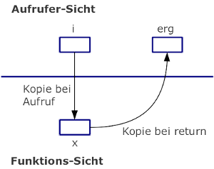

- Default in C ist die call-by-value Semantik:
  - Argumente werden bei Übergabe kopiert
  - Ergebniswerte werden bei Rückgabe kopiert
- Folgen:
  - Keine Seiteneffekte durch Verändern von übergebenen Strukturen
  - Negative Auswirkungen auf Laufzeit bei großen Daten

Ausnahme: Arrays (Verweis auf spätere VL)

Beispiel: vl02/cbv.c

## Globale Variablen (externe Variablen)

```c
int a = 1;

int main() {
    extern int a;
}
```

- Außerhalb **jeder** Funktion definierte Variablen
- Existieren die **gesamte** Programmlebensdauer über
- Müssen bei *Nutzung* in Funktionen als `extern` deklariert werden

=> Werden auch als **externe Variablen** bezeichnet

*Hinweis*: `extern` für globale Konstanten bedeutet etwas **leicht** anderes (=> später)

Varianten für Nutzung globaler Variablen in Funktionen:

- Deklaration der globalen Variable vor Funktionsdefinition:
  - In Funktion als `extern` deklarieren, oder
  - In Funktion direkt (ohne Deklaration) nutzen …
- Deklaration der globalen Variable nach Funktionsdefinition:
  - In Funktion als `extern` deklarieren

Konsole: vl02/extern.c

## Lokale Variablen (automatische Variablen)

```c
int b = 1;

void f() {
    int b = 42;
}

int main() {
    int b = 3;

    {
        int b = 7;
    }
}
```

- Innerhalb einer Funktion (oder Blockes) definierte Variablen
  - Gilt auch für Variablen aus Parameterliste
- Überdecken **globale Variablen** gleichen Namens
- Sichtbarkeit:
  - Außerhalb der Funktion/Blockes nicht zugreifbar
  - Beim Betreten der Funktion Reservierung von Speicherplatz für lokale Variablen
  - Dieser wird beim Verlassen des Blockes/Funktion automatisch wieder freigegeben
  - Namen sind nur nach Deklaration und innerhalb des Blockes, in dem sie deklariert wurden, gültig
  - Namen sind auch gültig für innerhalb des Blockes neu angelegte innere Blöcke

  Software Engineering: Vermeiden Sie lokale Namen, die Namen aus einem äußeren Scope überdecken!

=> Werden auch als **automatische Variablen** bezeichnet

Konsole: vl02/sichtbarkeit.c

## Schlüsselwort static

```c
void foo() {
    static int x = 42;
    x++;
    printf("x=%d\n", x);
}

int main() {
    foo();  foo();  foo();
}
```

- Lokale Variablen mit “Gedächtnis”:
  - Definition mit dem vorangestellten Schlüsselwort “static”

  ```c
  static int callCount;
  ```

- Eigenschaften:
  - Wert bleibt für die folgenden Funktionsaufrufe erhalten
  - Wert kann in der Funktion verändert werden
  - Dennoch: lokale Variable, d.h. von außen nicht sichtbar/gültig

*Hinweis*: `static` für globale Variablen bedeutet etwas anderes (=> später)

Beispiel: vl02/static.c

## Initialisierung

(Automatische) Initialisierung von Variablen hängt von ihrer Speicherklasse ab!

- Extern
  - Mit dem Wert 0 oder vorgegebenem Wert
  - Bereits vor Programmstart (im Code enthalten)
- Automatisch
  - Werden nicht automatisch initialisiert (!)
  - Bei vorgegebenem Wert ab Aufruf der Funktion
- Statisch
  - Mit dem Wert 0 oder vorgegebenem Wert
  - Ab erstem Aufruf der Funktion

Konsole: vl02/initVar.c

## Neuerungen bei Funktionen

- C99: `inline`-Funktionen:

  ```c
  inline void foo() { ... }
  ```

  - Aufrufe von `inline`-Funktionen können vom Compiler wie ein Makro direkt durch den Funktionskörper ersetzt werden
  - Vorteil: Compiler kann Verwendung (Parameter, Rückgabewert) prüfen

  Wird gern in der Programmierung von Embedded Systems eingesetzt, weil dadurch der eigentliche Funktionsaufruf und der damit verbundene Overhead (Ablegen der aktuellen Registerwerte auf dem Stack, Übergabe der Argumente auf dem Stack, Sprung in den Funktionscode, Abrufen der Parameter vom Stack, …) vermieden wird. (=> Vorgriff Speicherverwaltung)

  Bei Makros findet nur die Textersetzung statt, d.h. es findet dabei keine Prüfung statt, ob das Makro korrekt genutzt wird. (=> Vorgriff Präprozessor und Makros)
- C11: Funktionen ohne Wiederkehr: `_Noreturn`

  ```c
  _Noreturn void exit(int status);
  ```

  Sinnvoll, falls Funktion nie zum Aufrufer zurückkehrt, weil sie beispielsweise das Programm beendet. Durch die Markierung kann der Compiler zusätzliche Prüfungen, beispielsweise auf nicht erreichbaren Code hinter der Funktion, vornehmen.

# Zusammenfassung

## tl;dr

- Wichtigste Unterschiede zu Java
  - Kontrollfluss wie in Java
  - Basisdatentypen vorhanden
  - Typmodifikatoren zur Steuerung des Speicherbedarfs/Wertebereich
  - Kein `bool` (erst ab C99 als Makro) vorhanden
  - Integer können im booleschen Kontext ausgewertet werden
  - `printf()` stammt aus `stdio.h`, erinnert an `java.util.Formatter.format()`
- **Strukturen**: Kapselung von Daten mit `struct`
  - Schlüsselwort `struct` muss “mitgeschleppt” werden
  - Alternative: Definition eines neuen Typen mit `typedef`
- Aufzählungen, einfache Arrays
  - Arrays haben eine feste Länge
    - bei Deklaration als konstanten Ausdruck angeben (ANSI-C)
    - oder direkt bei Deklaration Initialisierung mit Initialisierungsliste und Compiler zählen lassen
    - ab C11: Größe des Arrays zur Laufzeit berechnen
- **Funktionen**: Kapselung von Operationen
  - Funktionen in C analog zu Methoden in Java
  - Existieren unabhängig von Klassen (gibt in C auch keine)
- Deklaration vs. Definition, Funktionsprototypen, **One-Definition-Rule**
- Parameterübergabe: **call-by-value** (Standard in C)
- Unterscheidung globale, lokale und lokale statische Variablen

**Nächste Woche**: Header-Dateien, Make, Virtueller Speicher

## Literatur zum Weiterlesen

- Goll und Dausmann (2014)
  - Allgemeines und Konventionen: Kapitel 4 und 6
  - Datentypen: Kapitel 7
  - Arrays: Abschnitt 8.3
  - Strukturen: Kapitel 13
  - Funktionen: Kapitel 11
  - Ausdrücke, Anweisungen, Operatoren: Kapitel 9
  - Kontrollstrukturen: Kapitel 10
- Wolf (2009)
  - Kapitel 1 bis 8
  - Funktionen: Kapitel 9
  - Strukturen: Kapitel 15
  - Arrays: Abschnitt 11.1
- Für Interessierte der “Klassiker” (Kernighan und Ritchie 2000); im Breymann (2011) finden sich ebenfalls Hinweise zu den obigen Themen (allerdings nicht sehr ausführlich)

### Bibliographie

Breymann, U. 2011. *Der C++ Programmierer*. 2. Auflage. Hanser. ISBN: 978-3-446-42691-7.

Goll, J.; und M. Dausmann. 2014. *C als erste Programmiersprache*. 8. Aufl. Springer Fachmedien Wiesbaden. DOI: 10.1007/978-3-8348-2271-0.

Kernighan, B. W.; und D. Ritchie. 2000. *The C Programming Language*. Prentice Hall. ISBN: 978-0-1311-0362-7.

Wolf, J. 2009. *C von A bis Z*. 3. Auflage. Rheinwerk Computing. ISBN: 978-3-8362-1411-7. URL: http://openbook.rheinwerk-verlag.de/c_von_a_bis_z/ (zugegriffen 03.08.2018).

## Lernziele – Nach dieser Vorlesung sollten Sie …

### Kennen (K1)

- Wichtigste Unterschiede und Gemeinsamkeiten zu Java

### Verstehen (K2)

- Unterschied zwischen Deklaration und Definition, One Definition Rule
- Problematik bei der Deklaration parameterloser Funktionen
- Call-by-Value-Semantik bei der Parameterübergabe
- Sichtbarkeit und Initialisierung von Variablen

### Anwenden (K3)

- Nutzung der Basisdatentypen einschließlich der Modifikatoren
- Deklaration von Variablen, Nutzung von Kontrollstrukturen und Operatoren
- Interpretation von Integers im booleschen Kontext
- Nutzung von bitweise wirkenden Operatoren
- Definition und Deklaration von Funktionen
- Nutzung lokaler und globaler und lokaler statischer Variablen
- Nutzung von Strukturen und Aufzählungen
- Einfache Ausgaben mit `printf()`

## Diese Fragen sollten Sie beantworten können …

### Datentypen in C

- Welche Basisdatentypen gibt es in C?
- Wie groß ist der Bereich der Basisdatentypen (Speicherbedarf, Zahlenbereich)? Wie können Sie das feststellen?

### C-Semantik, “Falsche Freunde” in C

- Warum ist der folgende Code gefährlich?

  ```c
  if (i=3)
  {
      printf("Vorsicht");
  }
  ```

  ```c
  if (i==3);
  {
      printf("Vorsicht");
  }
  ```

- Was ist das Ergebnis folgender Programme? Begründen Sie Ihre Antwort.

  ```c
  #include <stdio.h>

  int main() {
      unsigned char x = 0;
      unsigned char y = 3;

      if (x=y)
          printf("x: %d\n", x);
      else
          printf("y: %d\n", y);

      return 0;
  }
  ```

  ```c
  #include <stdio.h>

  int main() {
      short x = 0;
      short y = 3;
      short z = 2;

      if (x<y<z)
          printf("sortiert\n");
      else
          printf("unsortiert\n");

      return 0;
  }
  ```

### Variablen

- Erklären Sie den Unterschied zwischen automatischen und externen Variablen.
- Wie ist die Lebensdauer von lokalen statischen Variablen?
- Erklären Sie den Unterschied zwischen

  ```c
  int a=1;
  int main() {
      extern int a;
      return 0;
  }
  ```

  und

  ```c
  int a=1;
  int main() {
      int a = 4;
      return 0;
  }
  ```

### Funktionen

- Was ist ein Funktionsprototyp? Was geschieht, wenn dieser keine Parameter hat?
- Was ist der Unterschied zwischen der Deklaration und der Definition einer Funktion?

### ANSI-C

Ist dieser Code legales ANSI-C? Begründen Sie.

```c
int a=1;
int main() {
    extern int a = 4;
    return 0;
}
```

### “Falsche Freunde” in C

Betrachten Sie folgende Code-Ausschnitte. Erklären Sie, ob sich dort in Bezug auf (ANSI-) C ein Fehler versteckt und falls ja, wie dieser zu beheben wäre. Begründen Sie Ihre Antwort.

```c
/* Programm A */
double cube(int);
int cube(int);
```

```c
/* Programm B */
double square(double number) {
    double number;
    return number*number;
}
```

```c
/* Programm C */
float cube();           // function prototype
...
cube(float number) {    // function definition
    return number*number*number;
}
```

[^1]: Das ist aber dennoch eine statische Struktur, also kein dynamisches Array wie ein `vector` in Java!
[^2]: Achtung: C-Compiler akzeptiert **alle** Parameter!